# Prediction Models Project

## Initial Data Cleaning

First things first we download and read in the data.

```
##
##  /var/folders/y4/tf52djg96q5_5k8tdct04ynw0000gn/T//Rtmpoel8Qs/downloaded_packages
```

```
##
##  /var/folders/y4/tf52djg96q5_5k8tdct04ynw0000gn/T//Rtmpoel8Qs/downloaded_packages
```

We then set the seed for reproducibility and partition the training set so we can have a training and test set.

```r
set.seed(12345)

inTrain <- createDataPartition(y = training$classe, p = .6, list = FALSE)

training2 <- training[inTrain,]

testing <- training[-inTrain,]

head(str(training2))
```

```
## 'data.frame':    11776 obs. of  160 variables:
##  $ X                       : int  2 3 4 7 8 12 14 17 20 22 ...
##  $ user_name               : Factor w/ 6 levels "adelmo","carlitos",..: 2 2 2 2 2 2 2 2 2 2 ...
##  $ raw_timestamp_part_1    : int  1323084231 1323084231 1323084232 1323084232 1323084232 1323084232 1323084232 1323084232 1323084232 1323084232 ...
##  $ raw_timestamp_part_2    : int  808298 820366 120339 368296 440390 528316 576390 692324 788335 892313 ...
##  $ cvtd_timestamp          : Factor w/ 20 levels "02/12/2011 13:32",..: 9 9 9 9 9 9 9 9 9 9 ...
##  $ new_window              : Factor w/ 2 levels "no","yes": 1 1 1 1 1 1 1 1 1 1 ...
##  $ num_window              : int  11 11 12 12 12 12 12 12 12 12 ...
##  $ roll_belt               : num  1.41 1.42 1.48 1.42 1.42 1.43 1.42 1.51 1.59 1.57 ...
##  $ pitch_belt              : num  8.07 8.07 8.05 8.09 8.13 8.18 8.21 8.12 8.07 8.09 ...
##  $ yaw_belt                : num  -94.4 -94.4 -94.4 -94.4 -94.4 -94.4 -94.4 -94.4 -94.4 -94.4 ...
##  $ total_accel_belt        : int  3 3 3 3 3 3 3 3 3 3 ...
##  $ kurtosis_roll_belt      : Factor w/ 397 levels "","-0.016850",..: 1 1 1 1 1 1 1 1 1 1 ...
##  $ kurtosis_picth_belt     : Factor w/ 317 levels "","-0.021887",..: 1 1 1 1 1 1 1 1 1 1 ...
##  $ kurtosis_yaw_belt       : Factor w/ 2 levels "","#DIV/0!": 1 1 1 1 1 1 1 1 1 1 ...
```

[output cut: 86 more lines]

Taking a look at the data, we notice there are many variables that will not be helpful. Many columns are almost completely filled with NAs, while others have unhelpful entries like #DIV/0. We’ll do some cleanup so our data set is easier to work with.

## First Model

The data set is not very user-friendly. Unlike data on wages, little is known about what variables might affect correct arm curl form. Thus, we are stuck taking a stab in the dark. Let’s use principal components as a starting point.

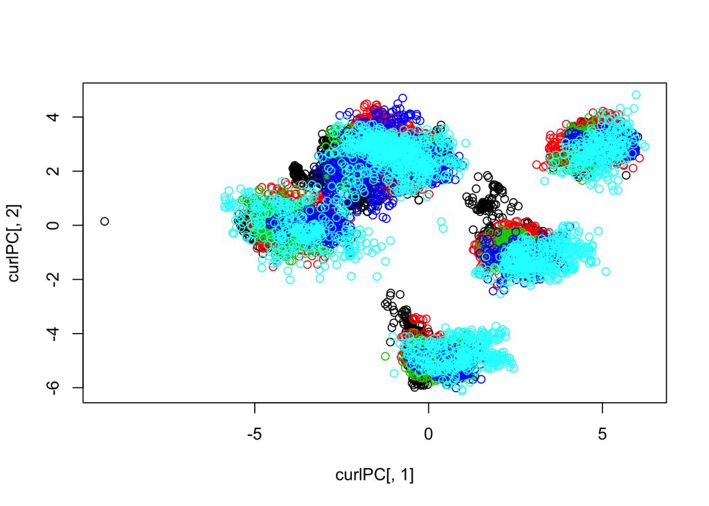

```r
preComp <- preProcess(complete.training[,-57], method = "pca", pcaComp = 2)

curlPC <- predict(preComp, complete.training[,-57])

plot(curlPC[,1],curlPC[,2], col = complete.training$classe)
```

While this initial analysis seems to have grouped the variables into five fairly distinct blobs, there seems to be little correlation with our variable of interest.

After other efforts, I eventually trying a Random Forest approach yielded good results.

```r
rfmod <- randomForest(classe ~ ., data = complete.training)

rfmod$confusion
```

```
##      A    B    C    D    E class.error
## A 3348    0    0    0    0   0.0000000
## B    0 2279    0    0    0   0.0000000
## C    0    1 2053    0    0   0.0004869
## D    0    0    0 1930    0   0.0000000
## E    0    0    0    0 2165   0.0000000
```

```r
confusionMatrix(testing$classe, predict(rfmod,testing))
```

```
## Confusion Matrix and Statistics
##
##           Reference
## Prediction    A    B    C    D    E
##          A 2232    0    0    0    0
##          B    0 1518    0    0    0
##          C    0    0 1368    0    0
##          D    0    0    0 1286    0
##          E    0    0    0    0 1442
##
## Overall Statistics
##
##                Accuracy : 1
##                  95% CI : (1, 1)
##     No Information Rate : 0.284
##     P-Value [Acc > NIR] : <2e-16
##
##                   Kappa : 1
##  Mcnemar's Test P-Value : NA
##
## Statistics by Class:
##
##                      Class: A Class: B Class: C Class: D Class: E
## Sensitivity             1.000    1.000    1.000    1.000    1.000
## Specificity             1.000    1.000    1.000    1.000    1.000
## Pos Pred Value          1.000    1.000    1.000    1.000    1.000
## Neg Pred Value          1.000    1.000    1.000    1.000    1.000
## Prevalence              0.284    0.193    0.174    0.164    0.184
## Detection Rate          0.284    0.193    0.174    0.164    0.184
## Detection Prevalence    0.284    0.193    0.174    0.164    0.184
## Balanced Accuracy       1.000    1.000    1.000    1.000    1.000
```

Obviously with 100% accuracy something fishy is going on here. Also odd that the testing set had higher accuracy than training. Unfortunately I was not able to figure out what was happening behind the scenes. While this seems to be a highly accurate (if overfitted) model, running it against the official testing set does not produce credible results.

## Conclusion

```r
answers = predict(rfmod, testingFinal)

answers
```

```
##  1  2  3  4  5  6  7  8  9 10 11 12 13 14 15 16 17 18 19 20
##  A  A  A  A  A  A  A  A  A  A  A  A  A  A  A  A  A  A  A  A
## Levels: A B C D E
```

Obviously these results are not very useful. While the user-created testing data set had an error rate of 0, this suggests the error rate is likely 72%.

```r
1-sum(training$classe == "A")/length(training$classe)
```

```
## [1] 0.7156
```